# NIH.AI Workshop: Predicting Drug Function Using Small-Molecule Structure Information

## Part 1: Generating Descriptor Data and Analysis

S.Ravichandran

```python
from IPython.display import clear_output
for i in range(10):
    clear_output(wait=True)
    print("Hello World!")
```

```
Hello World!
```

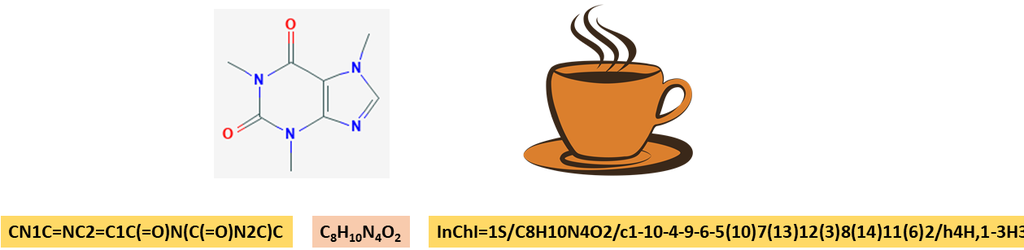

```python
from IPython.core.display import Image
Image(filename='Img/SMILES-Figures.png')
```

## Preliminary Information

Please click on this link to view the preliminary information about the workshop.

## Software-setup Information

Please click on this link here to see how to install the software needed this tutorial on your own system.

## Molecular/Chemical information

Please click on this link to read about the basics of molecular/chemical information (SMILES/SDF/PDB etc.). To visualize small molecules, we need atomic information. This can be obtained from different sources and formats (PubChem/DrugBank etc.; Formats: SMILES, PDB, Mol, sdf etc.). We will use SMILES strings for molecular information. There are many sources (check the last section, Supporting pages for details).

PubChem (https://pubchem.ncbi.nlm.nih.gov/) is a great resource for small molecule information. Please click on this link for a short demonstration on how to search for compounds in PubChem library.

## Load the libraries

```python
import os
import numpy as np
import pandas as pd
import warnings
warnings.filterwarnings('ignore')
from IPython.core.display import Image

from rdkit import Chem
from rdkit.Chem import AllChem
from rdkit.Chem import Draw
from rdkit.Chem import rdDepictor
from rdkit.Chem import PandasTools
from rdkit.Chem.Draw import IPythonConsole
from rdkit.Chem.Draw.MolDrawing import MolDrawing, DrawingOptions
from rdkit.Chem.Draw import IPythonConsole
from concurrent import futures
from rdkit.Chem import Draw
from rdkit.Chem import rdDepictor
IPythonConsole.molSize = (450,200)
```

```
RDKit WARNING: [12:44:02] Enabling RDKit 2019.09.3 jupyter extensions
```

### Chemoinformatics library, rdkit, for small-molecule feature generation/analysis

Go to the following link, https://www.rdkit.org/, to learn about rdkit. If you have questions about how to use I recommend you to visit a detailed version of this workshop

Please note that rdkit is a powerful chemoinformatics software. It can be used to read, compute (energy-minimization), visualize, create quality-figures and analyze both small molecule and protein sequences/structures. Please visit my github repo to learn about how to use rdkit for these tasks, https://github.com/ravichas/SRWkshp1

### We can display proteins/small-molecules before computing properties

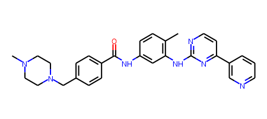

```python
imatinib = 'CC1=C(C=C(C=C1)NC(=O)C2=CC=C(C=C2)CN3CCN(CC3)C)NC4=NC=CC(=N4)C5=CN=CC=C5'
imatinib_m = Chem.MolFromSmiles(imatinib)
rdDepictor.SetPreferCoordGen(True)
rdDepictor.Compute2DCoords(imatinib_m)
imatinib_m
```

```python
import py3Dmol

# The crystal structure of COVID-19 main protease in complex with an inhibitor N3
# The main protease (enzyme that catalyses/cuts proteins into smaller fragments) of coronavirus makes most of these cuts. The one shown here
# (PDB entry 6lu7) is from the SARS-CoV-2 (or 2019-nCoV) coronavirus that is currently posing dangers in Wuhan

view = py3Dmol.view(query='pdb:6lu7')
view.setStyle({'cartoon':{'color':'spectrum'}})
```

```
<py3Dmol.view at 0x284ed9b8370>
```

## Generating molecular properties

For this section, we will be using cdkit and Mordred (a molecular descriptor calculator) to generate molecular descriptors. Follow the links shown below for information on mordred calculator:

- https://jcheminf.biomedcentral.com/articles/10.1186/s13321-018-0258-y
- https://github.com/mordred-descriptor/mordred

## Molecular fingerprints

We will use Morgan Fringerprints. You can read about the details here, https://www.ncbi.nlm.nih.gov/pubmed/20426451 and here, https://www.daylight.com/dayhtml/doc/theory/theory.finger.html

Note most of the ideas are based on examples from cdkit manual. In a nutshell, each fragment in a molecule correspond to a bit. Two similar molecular fingerprints will have many common bits.

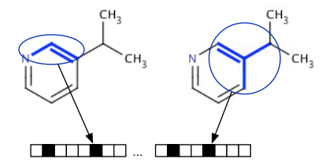

```python
Image(filename='Img/FPComp.PNG',width = 300, height = 300 )
# (Following figure is based on an an online presentation)
```

We are going to use fingerprint as features that define molecule. To explain the idea, let us use the two pain-killer drugs, paracetamol and pheacetin (withdrawn) as an example. First let us visualize, compute and analyze both the molecule and its fingerprint.

```python
IPythonConsole.molSize = (450,200)

# fever reducer
paracetamol = 'CC(=O)NC1=CC=C(O)C=C1'
paracetamol_m = Chem.MolFromSmiles(paracetamol)
rdDepictor.Compute2DCoords(paracetamol_m)

# withdrawn fever reducer
phenacetin = 'CCOC1=CC=C(NC(C)=O)C=C1'
phenacetin_m = Chem.MolFromSmiles(phenacetin)
rdDepictor.Compute2DCoords(phenacetin_m)

mols = [paracetamol_m, phenacetin_m]
mols
```

```
[<rdkit.Chem.rdchem.Mol at 0x284f0522a30>,
 <rdkit.Chem.rdchem.Mol at 0x284f0522530>]
```

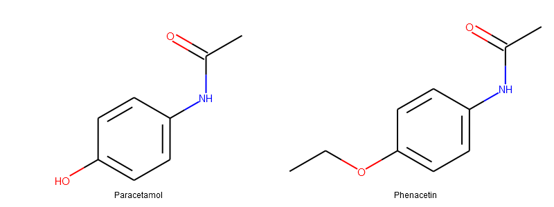

```python
Draw.MolsToGridImage(mols, subImgSize=(400, 300), molsPerRow = 2, legends = ['Paracetamol','Phenacetin'])
```

### We can convert fingerprint to bits and view them

```python
bi1 = {}
fp1 = AllChem.GetMorganFingerprintAsBitVect(paracetamol_m, radius=2, bitInfo=bi1)
bits1 = fp1.ToBitString()
print(len(bits1))
bits1
```

```
2048
```

```
'000000000000000000000000000000000000000000000000000000000000…'
```

```python
print(len(list(fp1.GetOnBits())))
print(list(fp1.GetOnBits()) )
```

```
20
[191, 245, 530, 650, 745, 807, 843, 849, 1017, 1057, 1077, 1152, 1313, 1380, 1602, 1750, 1778, 1816, 1873, 1917]
```

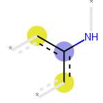

```python
# In its simplest form, the new code lets you display the atomic environment that sets a particular bit. Here we will look at bit 589:
Draw.DrawMorganBit(paracetamol_m,191,bi1)
```

Let us check whether Phencetin have the same fragment?

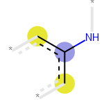

```python
bi2 = {}
fp2 = AllChem.GetMorganFingerprintAsBitVect(phenacetin_m, radius=2, bitInfo=bi2)
bits2 = fp2.ToBitString()
# In its simplest form, the new code lets you display the atomic environment that sets a particular bit. Here we will look at bit 589:
Draw.DrawMorganBit(phenacetin_m,191,bi2)
```

## Mordred: For computing descriptors

We will be using a python package called mordred for generating descriptors. Mordred Github Page: https://github.com/mordred-descriptor/mordred and click here to see the complete list of mordred descriptors, https://mordred-descriptor.github.io/documentation/master/descriptors.html

### Compute molecular descriptors for a library of small-molecules

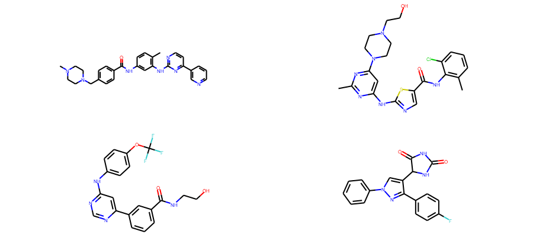

```python
from rdkit import Chem
from mordred import Calculator, descriptors

# create descriptor calculator with all descriptors
calc = Calculator(descriptors, ignore_3D=True)

IPythonConsole.molSize = (450,400)
dasatinib = 'CC1=C(C(=CC=C1)Cl)NC(=O)C2=CN=C(S2)NC3=CC(=NC(=N3)C)N4CCN(CC4)CCO'
dasatinib_m = Chem.MolFromSmiles(dasatinib)
gnf5 = 'C1=CC(=CC(=C1)C(=O)NCCO)C2=CC(=NC=N2)NC3=CC=C(C=C3)OC(F)(F)F'
gnf5_m = Chem.MolFromSmiles(gnf5)
dph = 'C1=CC=C(C=C1)N2C=C(C(=N2)C3=CC=C(C=C3)F)C4C(=O)NC(=O)N4'
dph_m = Chem.MolFromSmiles(dph)

molecules = [ imatinib_m, dasatinib_m, gnf5_m, dph_m ]
Draw.MolsToGridImage(molecules, molsPerRow = 2, subImgSize=(450, 200))
```

**Please inspect the descriptor table before you use them in other calculations. Especially when you are generating all the descriptors, some of the columns may contain NA or Nan etc.**

```python
# calculate multiple molecule
mols = [Chem.MolFromSmiles(smi) for smi in [imatinib, dasatinib, gnf5, dph]]

# as pandas
df = calc.pandas(mols)
```

```python
df
```

|  | ABC | ABCGG | nAcid | nBase | SpAbs_A | SpMax_A | SpDiam_A | SpAD_A | SpMAD_A | LogEE_A | ... | SRW10 | TSRW10 | MW | AMW | WPath | WPol | Zagreb1 | Zagreb2 | mZagreb1 | mZagreb2 |
| --- | --- | --- | --- | --- | --- | --- | --- | --- | --- | --- | --- | --- | --- | --- | --- | --- | --- | --- | --- | --- | --- |
| 0 | 29.198227 | 19.516970 | 0 | 2 | 49.161634 | 2.372244 | 4.744487 | 49.161634 | 1.328693 | 4.541483 | ... | 10.415502 | 73.587263 | 493.259009 | 7.253809 | 5324 | 56 | 194.0 | 224.0 | 9.972222 | 8.083333 |
| 1 | 25.731643 | 19.151718 | 0 | 1 | 42.312870 | 2.394767 | 4.762938 | 42.312870 | 1.282208 | 4.422390 | ... | 10.323283 | 82.603238 | 487.155722 | 8.256877 | 3723 | 50 | 172.0 | 200.0 | 10.472222 | 7.277778 |
| 2 | 23.132682 | 16.941805 | 0 | 0 | 38.063201 | 2.370962 | 4.741923 | 38.063201 | 1.268773 | 4.312334 | ... | 10.143881 | 65.313648 | 418.125275 | 8.896282 | 2918 | 42 | 152.0 | 171.0 | 10.090278 | 6.597222 |
| 3 | 19.924959 | 16.140292 | 0 | 0 | 32.867760 | 2.498596 | 4.828813 | 32.867760 | 1.314710 | 4.170130 | ... | 10.150621 | 75.953704 | 336.102254 | 8.844796 | 1431 | 38 | 136.0 | 162.0 | 7.250000 | 5.388889 |

4 rows × 1613 columns

Please [visit](https://github.com/ravichas/SRWkshp1) GitHub repository to see additional examples and take-home exercises.

## Part 2: Machine Learning for Predicing Drug Function Using Molecular Structures

Please check out a detailed version of this project from https://github.com/ravichas/SRWkshp1a

## Preliminary Information

We will use the following manuscript as a testcase to explain the Machine-Learning concepts:

https://www.ncbi.nlm.nih.gov/pubmed/31518132

Overview of the work:

- Chemical structures with MeSH derived therapeutic drug classes are the inputs.
- **Random Forest (RF)** Machine-Learning (ML) method and **Convolution Neural Network** was used for classification. For this workshop, we fill focus on RF for this workshop.

### Here is a schematic overview of the modeling procedure

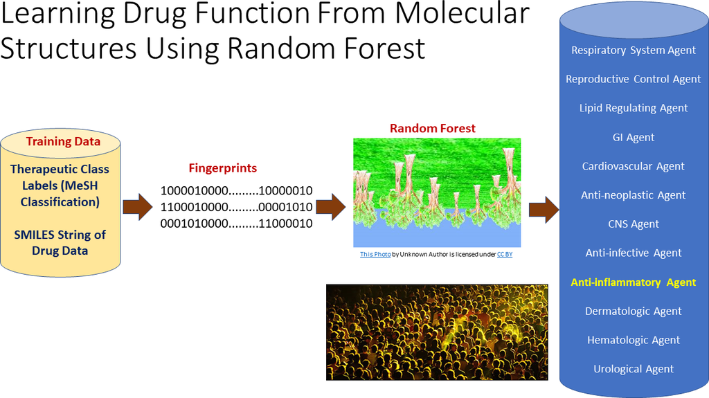

```python
from IPython.display import Image
Image('Img/DrugFunctionModeling-banner.png', width=900, height=900)
```

### To create drug function classifier models, we need two things:

- Chemical structures and their associated class labels
- Descriptors (Fingerprints)

Input dataset can be constructed using PubChem (https://pubchem.ncbi.nlm.nih.gov/). You can check my Github repository for details, https://github.com/ravichas/SRWkshp1a (section 4 on the ML-UsingSmallMoleculeData.ipynb)

```python
## Preliminary library setup
import os, random, time, numpy as np
import matplotlib.pyplot as plt
from collections import Counter
from rdkit import Chem, DataStructs
from rdkit.Chem import Draw
from sklearn import preprocessing
from sklearn.ensemble import RandomForestClassifier
```

## Load the data

```python
import pandas as pd
df3  = pd.read_csv('Data/3cls_rmsaltol.csv')

# five class dataset
df5  = pd.read_csv('Data/5cls_rmsaltol.csv')

print("Here are few first/last 5 lines of the df3 data")
df3
```

```
Here are few first/last 5 lines of the df3 data
```

|  | pngpath | class | smiles |
| --- | --- | --- | --- |
| 0 | cns/1 | cns | O=C1CC=CO1 |
| 1 | cns/2 | cns | CCC(=O)O[C@@]1(c2ccccc2)C[C@H](C)N(C)C[C@H]1C |
| 2 | cns/3 | cns | C=CCC(N)C(=O)O |
| 3 | cns/4 | cns | CC[C@@]12CCN(CC3CC3)[C@@H](C(=O)c3ccc(O)cc31)C2C |
| 4 | cns/5 | cns | c1csc(C2(N3CCCCC3)CCCCC2)c1 |
| ... | ... | ... | ... |
| 3099 | cardio/783 | cardio | CN=C(NCc1ccccc1)[NH2+]C.CN=C(NCc1ccccc1)[NH2+]C |
| 3100 | cardio/784 | cardio | CC1O[C@@H](O[C@@H]2C=C3CC[C@@H]4[C@H](CC[C@]5(... |
| 3101 | cardio/785 | cardio | O=C(Nc1ccc(C([O-])=Nc2cc(S(=O)(=O)[O-])cc3cc(S... |
| 3102 | cardio/786 | cardio | CCC(=O)OC(OP(=O)(CCCCc1ccccc1)CC(=O)N1CC(C2CCC... |
| 3103 | cardio/787 | cardio | Cc1cccc(C)c1NC(=O)C(C)N |

3104 rows × 3 columns

### Explore the dataset

```python
# All the data
print('Dimension of 3-class dataset', df3.shape)
print('Dimension of 5-class dataset', df5.shape)
# print('Dimension of 12-class dataset', df12.shape, '\n')
```

```
Dimension of 3-class dataset (3104, 3)
Dimension of 5-class dataset (5760, 3)
```

#### **Assign a specific dataset for modeling/analysis?**

For choosing a 3-class data, use `df = df3`

For choosing a 5-class data, use `df = df5`

For now, we are going to use `3-class data` for modeling.

```python
## Assign a dataset for analysis
df = df3
```

## Prepare the data for modeling

Encode target labels with value between 0 and n_classes-1.

```python
x = df['smiles'].values

mols1 = [Chem.MolFromSmiles(smi) for smi in x]
outcome = df['class'].values

le = preprocessing.LabelEncoder()
le.fit(outcome);
print('What labels are available in classes?:', list(le.classes_))
ys_fit = le.transform(outcome)

print('transformed outcome:  ', ys_fit)
```

```
What labels are available in classes?: ['antineoplastic', 'cardio', 'cns']
transformed outcome:   [2 2 2 ... 1 1 1]
```

From the above analysis, for a 3-class, df3a data, we see that

```
0: Antineoplastic Agents (antineoplastic)
1: Cardiovascular Agents (cardio)
2: Central Nervous System Agents (cns)
```

## Data Analysis

Let us answer the following questions:

- How many Classes/Samples?
- Is this a balanced outcome data?

```python
bin_count = np.bincount(ys_fit)
n_classes = len(bin_count)
print('How many classes? ',n_classes)
print('How many samples? ', len(ys_fit) )

print('How many from each class (raw numbers)? ', bin_count )
print('How many from each class (proportions)?: ', bin_count/(sum(bin_count)))
```

```
How many classes?  3
How many samples?  3104
How many from each class (raw numbers)?  [1177  788 1139]
How many from each class (proportions)?:  [0.37918814 0.25386598 0.36694588]
```

## Generate fingeprints:

Read the following paper for details, https://www.ncbi.nlm.nih.gov/pubmed/20426451

```python
# Time to generate the Fingerprints: 8.323498249053955 seconds on core i7 laptop

time_start = time.time()

from rdkit.Chem import AllChem
fp1 = [AllChem.GetMorganFingerprintAsBitVect(m, 2, nBits=1024) for m in mols1]

# convert RDKit explicit vectors into NUMPY array
np_fps = np.asarray(fp1)

time_elapsed = time.time()-time_start
txt = 'Time to generate the Fingerprints: {} seconds '
print(txt.format(time_elapsed))
```

```
Time to generate the Fingerprints: 6.746112585067749 seconds
```

```python
print(np_fps[0:10,0:20])
```

```
[[0 0 0 0 0 0 0 0 0 0 0 0 0 0 0 0 0 0 0 0]
 [0 0 0 0 0 0 0 0 0 0 0 0 0 0 0 0 0 0 0 0]
 [0 1 0 0 0 0 0 0 0 0 0 0 1 0 0 0 0 0 0 0]
 [0 0 0 0 0 0 0 0 0 0 0 0 0 0 0 0 0 0 0 0]
 [0 0 1 0 1 0 0 0 0 0 0 0 0 0 1 0 0 0 0 0]
 [0 0 0 1 1 0 0 0 0 0 0 0 0 0 0 0 0 0 0 0]
 [0 0 0 0 0 0 0 0 0 0 0 1 0 0 0 0 0 0 0 0]
 [0 1 0 0 1 0 0 0 0 0 0 0 0 0 0 0 0 0 0 0]
 [0 1 0 0 0 0 0 0 0 0 0 0 0 0 0 0 0 0 0 0]
 [0 0 0 0 0 0 0 0 0 0 0 1 0 0 0 0 0 0 0 0]]
```

## Getting ready to do modeling

First, let us split the data

```python
from sklearn.model_selection import train_test_split

train_X, test_X, train_y, test_y = train_test_split(np_fps, ys_fit,
                                                    train_size=0.75,
                                                    test_size=0.25,
                                                    random_state=123,
                                                    stratify = ys_fit)
train_y = list(train_y)
test_y = list(test_y)
```

### Explore the proportion of outcomes to answer questions about data imbalance

```python
# Even outcome for this class
np.bincount(ys_fit)/len(ys_fit)
```

```
array([0.37918814, 0.25386598, 0.36694588])
```

## Supervised Learning using Random Forest

We will use Random-Forest based classifier for classification.

#### Why we are focussing on Random Forest?

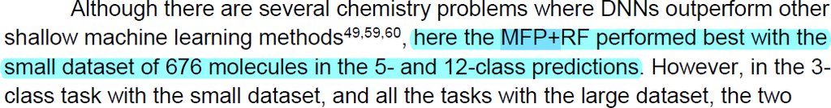

```python
Image('Img/PaperSummary1.png')
```

```python
# get a random forest classifiert with 100 trees
rf = RandomForestClassifier(n_estimators=50, random_state=1123)
```

```python
from pprint import pprint
# View the parameters of the random forest
print('Parameters will be used for this model:\n')
pprint(rf.get_params())
```

```
Parameters will be used for this model:

{'bootstrap': True,
 'ccp_alpha': 0.0,
 'class_weight': None,
 'criterion': 'gini',
 'max_depth': None,
 'max_features': 'auto',
 'max_leaf_nodes': None,
 'max_samples': None,
 'min_impurity_decrease': 0.0,
 'min_impurity_split': None,
 'min_samples_leaf': 1,
 'min_samples_split': 2,
 'min_weight_fraction_leaf': 0.0,
 'n_estimators': 50,
 'n_jobs': None,
 'oob_score': False,
 'random_state': 1123,
 'verbose': 0,
 'warm_start': False}
```

```python
# train the random forest
rf.fit(train_X, train_y);
```

```python
from sklearn import metrics
from sklearn.metrics import balanced_accuracy_score

pred_y = rf.predict(test_X)
acc = metrics.accuracy_score(test_y, pred_y)
print("Test set accuracy: {:.2f}".format(acc))

balanced_acc_score = balanced_accuracy_score(test_y, pred_y)
print("Balanced set Accuracy Score: {:.2f}".format(balanced_acc_score))
```

```
Test set accuracy: 0.87
Balanced set Accuracy Score: 0.86
```

```
Normalized confusion matrix
[[0.901 0.014 0.085]
 [0.076 0.756 0.168]
 [0.081 0.011 0.909]]
```

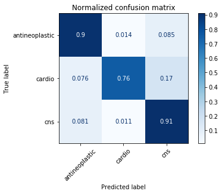

```python
# Plot non-normalized confusion matrix
# get a random forest classifiert with 100 trees
np.set_printoptions(precision=3)
from sklearn.metrics import plot_confusion_matrix

titles_options = [("Normalized confusion matrix", 'true')]

for title, normalize in titles_options:
    disp = plot_confusion_matrix(rf, test_X, test_y,
                                 display_labels=le.classes_,
                                 cmap=plt.cm.Blues,
                                 normalize=normalize)
    disp.ax_.set_title(title)
    plt.xticks(rotation=45)

    print(title)
    print(disp.confusion_matrix)

plt.show()
```

## Inference

```
0: Antineoplastic Agents (antineoplastic)
1: Cardiovascular Agents (cardio)
2: Central Nervous System Agents (cns)
```

```python
print(rf.predict(test_X[10:13]))
print(test_y[10:13])
# pred_y = rf_best_grid.predict(test_X)
```

```
[0 1 0]
[0, 1, 0]
```

## Questions

- Can molecular features (Ex. Mol Wt., # of HBD, # of HBA) are implicitely captured by this fingerprints?
- Cardio drugs seems to have similar properties for the model to be confused

### In the paper, using the 5-label dataset, they had identified drugs that were misclassified and upon inspection seems to have structures similar to the misclassified class.

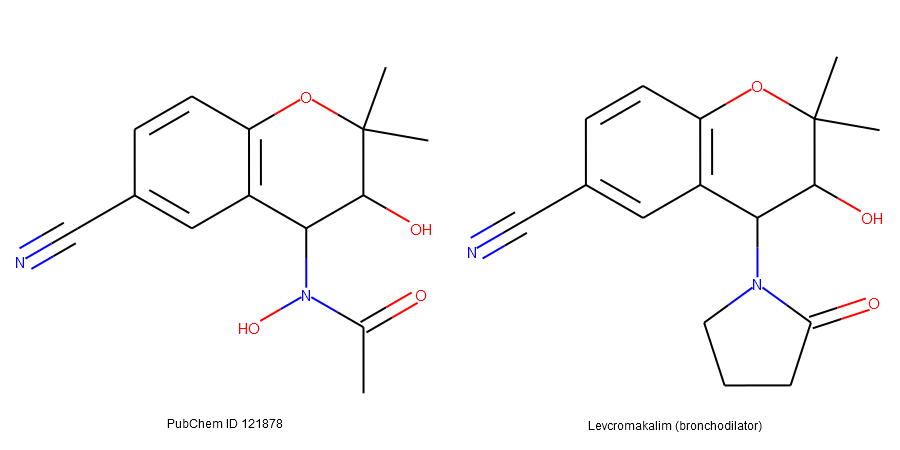

```python
# misclassified as a respiratory system drug
cid_121878 = 'CC(=O)N(C1C(C(OC2=C1C=C(C=C2)C#N)(C)C)O)O'
cid_121878_m = Chem.MolFromSmiles(cid_121878)

rdDepictor.SetPreferCoordGen(True)
rdDepictor.Compute2DCoords(cid_121878_m)
# similarity with bronchodilator molecule
cid_93504 = 'CC1(C(C(C2=C(O1)C=CC(=C2)C#N)N3CCCC3=O)O)C'
cid_93504_m = Chem.MolFromSmiles(cid_93504)
rdDepictor.Compute2DCoords(cid_93504_m)


molecules = [ cid_121878_m, cid_93504_m ]
Draw.MolsToGridImage(molecules, molsPerRow = 2,
                     subImgSize=(450, 450),
                     legends = ['PubChem ID 121878', 'Levcromakalim (bronchodilator)'])
```

## Final thoughts

### Can the model misclassification is due to lack of training and nothing to do with repurposing?

## How can we improve the models?

There are several parametes (number of estimators, maximum features etc.) that could be assigned different values. These parameters are commonly referred to as Hyperparameters. Choosing the right combination is called HyperParameter Optimization (HPO).

## Hyperparameter values (HP) and HP Optimization (HPO)

For ScikitLearn implementation of RandomForest, we can adjust several HP values. Here is the complete list:

```
{'bootstrap': True,
 'ccp_alpha': 0.0,
 'class_weight': None,
 'criterion': 'gini',
 'max_depth': None,
 'max_features': 'auto',
 'max_leaf_nodes': None,
 'max_samples': None,
 'min_impurity_decrease': 0.0,
 'min_impurity_split': None,
 'min_samples_leaf': 1,
 'min_samples_split': 2,
 'min_weight_fraction_leaf': 0.0,
 'n_estimators': 50,
 'n_jobs': None,
 'oob_score': False,
 'random_state': 1123,
 'verbose': 0,
 'warm_start': False}
```

Where do we start? The best option is to read the documentation, https://scikit-learn.org/stable/modules/generated/sklearn.ensemble.RandomForestClassifier.html. We have adopted the following choices based on the manuscript.

| Parameter | Values |
| --- | --- |
| n_estimators | 50, 250, 1000, 4000, 8000, 16000 |
| max_features | sqrt, log2 |
| min_samples_leaf | 1, 10, 100, 1000 |
| class_weight | None, balanced_subsample, balanced |

A HPO `RandomizedSearchCV` run was carried out in NIH HPC with the list shown in the table and found the following best combination.

| Parameter | Values |
| --- | --- |
| n_estimators | 8000 |
| max_features | log2 |
| min_samples_leaf | 1 |
| class_weight | balanced |

**Acknowledgements:** Drs. George Zaki, Andrew Weisman, Randy Johnson, Hue Reardon, Anney Che and Jaume Reventos for attending the mockup talks and suggestions. I would also like to thank FNLCR BIDS colleagues for reviewing the materials.